# Module 3 Project, Part A: Check Your Numbers

This is the output of one complete run of the project, with a fixed random seed. Use it to see whether your own results are in the right ballpark: the same order of magnitude, the same conclusions, the same first digit or two. It is not an answer key. There is no code and no explanation here, and the exam asks about *your* project, not this one.

What should match, and how closely:

- **Exact values** do not depend on random numbers and should match to every digit shown: $s/\sqrt n$ and $r$ in A.1, and $\hat G$ and the difference in A.2.
- **Bootstrap estimates** vary from run to run. Your SEs and interval endpoints should agree with these to about two significant digits.

# Part A: The bootstrap

## A.1

The bootstrap SE of the mean from 2,000 samples, then $s / \sqrt n$.

```
## bootstrap   formula
##  72.31962  71.65035
```

The scatterplot and $r$, the bootstrap SE, then the normal, basic and percentile intervals.

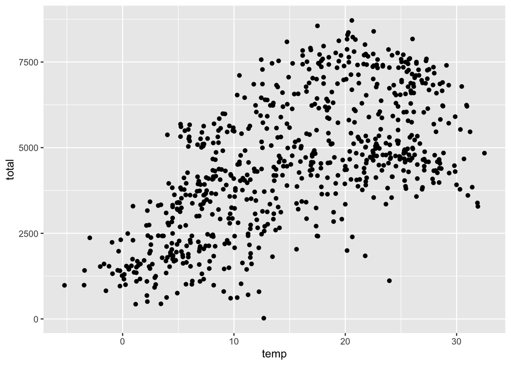

```
## [1] 0.627504
```

```
## [1] 0.01939804
```

```
##                 [,1]      [,2]
## normal     0.5894845 0.6655235
## basic      0.5899201 0.6662178
## percentile 0.5887902 0.6650879
```

## A.2

`gini` on 10,000 exponential draws, whose $G$ is 1/2.

```
## [1] 0.5042727
```

$\hat G$ for casual and registered riders and their difference, the SE and percentile interval of the difference, then the paired SE beside the SE from independent samples.

```
##     casual registered
##  0.4297582  0.2439905
```

```
## [1] 0.1857677
```

```
##          se        2.5%       97.5%
## 0.009532183 0.165672733 0.203410786
```

```
##      paired       apart
## 0.009532183 0.011409334
```

## A.3

The fraction of bootstrap minima equal to the observed minimum and the value (a) predicts, the table of bootstrap minima, then the percentile interval.

```
##  fraction predicted
## 0.6230000 0.6323723
```

```
## m_boot
##   22  431  441  506  605  623  627  683  705
## 1246  465  184   61   32    6    3    2    1
```

```
##  2.5% 97.5%
##    22   506
```